# Loan data- Multiple regression

2024-04-15

1. Model Development

```r
loan_data <- read.csv("C:/Users/rusha/Downloads/Multivariate/credit_risk_dataset.csv/credit_risk_dataset.csv")
str(loan_data)
```

```
## 'data.frame':    498 obs. of  10 variables:
##  $ person_age                : int  22 21 25 23 24 21 26 24 24 21 ...
##  $ loan_status               : int  1 0 1 1 1 1 1 1 1 1 ...
##  $ person_income             : int  59000 9600 9600 65500 54400 9900 77100 78956 83000 10000 ...
##  $ person_emp_length         : int  12 5 1 4 8 2 8 5 8 6 ...
##  $ loan_amnt                 : int  35000 1000 5500 35000 35000 2500 35000 35000 35000 1600 ...
##  $ loan_int_rate             : num  16 11.1 12.9 15.2 14.3 ...
##  $ loan_percent_income       : num  0.59 0.1 0.57 0.53 0.55 0.25 0.45 0.44 0.42 0.16 ...
##  $ cb_person_cred_hist_length: int  3 2 3 2 4 2 3 4 2 3 ...
##  $ loan_grade                : chr  "D" "B" "C" "C" ...
##  $ cb_person_default_on_file : chr  "Y" "N" "N" "N" ...
```

```r
#loan_data_numeric <- as.data.frame(sapply(loan_data, as.numeric))
model_fit <- lm(loan_status ~ person_income + loan_amnt + loan_int_rate + cb_person_cred_hist_length + cb_person_default_on_file, data = loan_data)
summary(model_fit)
```

```
##
## Call:
## lm(formula = loan_status ~ person_income + loan_amnt + loan_int_rate +
##     cb_person_cred_hist_length + cb_person_default_on_file, data = loan_data)
##
## Residuals:
##     Min      1Q  Median      3Q     Max
## -0.8450 -0.2286  0.1063  0.2476  1.1934
##
## Coefficients:
##                              Estimate Std. Error t value Pr(>|t|)
## (Intercept)                 6.091e-01  1.012e-01   6.021 3.66e-09 ***
## person_income              -4.572e-06  2.380e-07 -19.209  < 2e-16 ***
## loan_amnt                   1.073e-05  1.864e-06   5.757 1.61e-08 ***
## loan_int_rate               2.467e-02  6.049e-03   4.079 5.36e-05 ***
## cb_person_cred_hist_length -3.373e-02  2.091e-02  -1.613    0.107
## cb_person_default_on_fileY  9.720e-03  4.471e-02   0.217    0.828
## ---
## Signif. codes:  0 '***' 0.001 '**' 0.01 '*' 0.05 '.' 0.1 ' ' 1
##
## Residual standard error: 0.3601 on 440 degrees of freedom
##   (52 observations deleted due to missingness)
## Multiple R-squared:  0.4823, Adjusted R-squared:  0.4764
## F-statistic: 81.99 on 5 and 440 DF,  p-value: < 2.2e-16
```

```r
coefficients(model_fit)
```

```
##                (Intercept)              person_income
##               6.090838e-01              -4.571839e-06
##                  loan_amnt              loan_int_rate
##               1.072819e-05               2.467403e-02
## cb_person_cred_hist_length cb_person_default_on_fileY
##              -3.373381e-02               9.720351e-03
```

Intercept: indicates the estimated value of the dependent variable (loan_status) when all predictor variables are zero. 0.6091.

For a one-unit increase in person_income, the expected change in loan_status is a decrease of approximately 0.00000457. Very low p-value (< 0.001), i.e has a significant effect.

For a one-unit increase in loan_amnt, the expected change in loan_status is an increase of approximately 0.00001073. very low p-value (< 0.001), i.e significant effect.

For a one-unit increase in loan_int_rate, the expected change in loan_status is an increase of approximately 0.02467. very low p-value (< 0.001), i.e significant effect.

For a one-unit increase in cb_person_cred_hist_length, the expected change in loan_status is a decrease of approximately 0.03373. p-value for this coefficient is 0.107, i.e not statistically significant.

For cb_person_default_on_file set to ‘Y’ (yes) results in an increase of approximately 0.00972 in the expected value of loan_status. p-value for this coefficient is 0.828, i.e not statistically significant.

The Adjusted R-squared value is approximately 0.4764, indicating that the model explains about 47.64% of the variability in loan_status. The F-statistic is 81.99 with a p-value < 0.001, indicating that the overall model is statistically significant.

loan_status has statistically significant predictors (person_income, loan_amnt, and loan_int_rate). However, some predictors (cb_person_cred_hist_length and cb_person_default_on_fileY) are not statistically significant.

2. Model Acceptance

```r
# Assess the acceptance of the model
# Check R-squared and adjusted R-squared
r_squared <- summary(model_fit)$r.squared
adj_r_squared <- summary(model_fit)$adj.r.squared
cat("R-squared:", r_squared, "\n")
```

```
## R-squared: 0.4823119
```

```r
cat("Adjusted R-squared:", adj_r_squared, "\n")
```

```
## Adjusted R-squared: 0.4764291
```

```r
# Check the F-statistic and its p-value
f_statistic <- summary(model_fit)$fstatistic
f_statistic_value <- f_statistic[1]
f_statistic_p_value <- pf(f_statistic_value, f_statistic[2], f_statistic[3], lower.tail = FALSE)
cat("F-statistic:", f_statistic_value, "\n")
```

```
## F-statistic: 81.98651
```

```r
cat("p-value:", f_statistic_p_value, "\n")
```

```
## p-value: 1.039549e-60
```

R-squared (0.4823) indicates that approximately 48.23% of the variability in the dependent variable (loan_status) is explained by the model. Adjusted R-squared (0.4764) adjusts the R-squared value for the number of predictors in the model. It is slightly lower than R-squared, suggesting that adding more predictors may not significantly improve the model’s explanatory power.

The F-statistic (81.98651) tests the overall significance of the model. It compares the fit of the model with no predictors (null model) against the fit of the current model. The associated p-value (1.039549e-60) is extremely low, indicating strong evidence against the null hypothesis (that the model has no predictive power).

However, the model appears to have some predictive power and explanatory value, there may be opportunities to refine the model by considering additional predictors or exploring alternative modeling techniques.

3. Residual Analysis

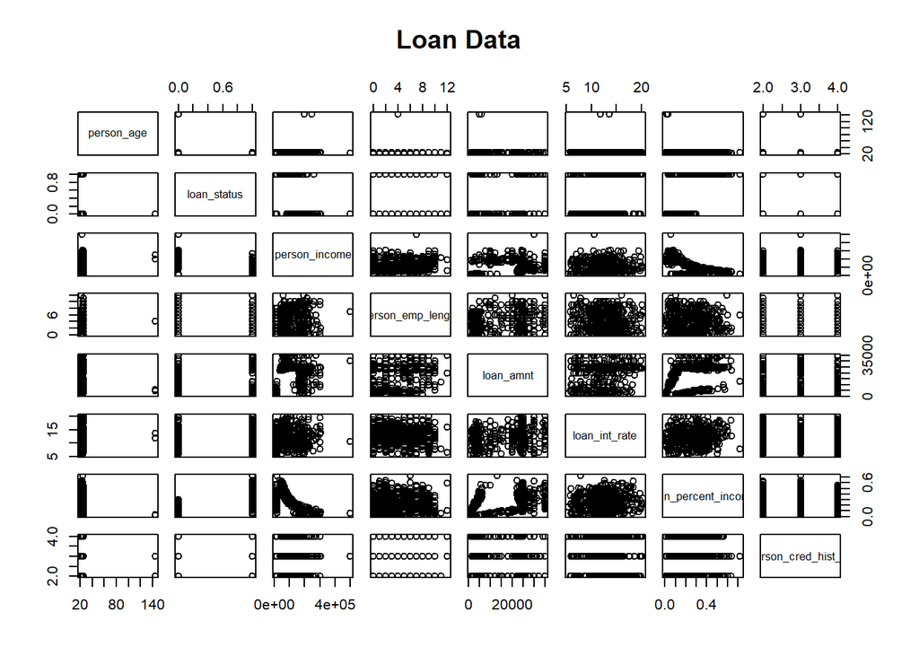

```r
# Select only numeric variables from fish_data
numeric_loan_data <- loan_data[, sapply(loan_data, is.numeric)]
# Plot pairs
pairs(numeric_loan_data, main = "Loan Data")
```

```r
confint(model_fit,level=0.95)
```

```
##                                    2.5 %        97.5 %
## (Intercept)                 4.102634e-01  8.079042e-01
## person_income              -5.039604e-06 -4.104073e-06
## loan_amnt                   7.065586e-06  1.439080e-05
## loan_int_rate               1.278614e-02  3.656192e-02
## cb_person_cred_hist_length -7.483782e-02  7.370193e-03
## cb_person_default_on_fileY -7.814262e-02  9.758332e-02
```

```r
fitted(model_fit)
```

```
##            1            2            3            4            5            6
##  1.018628937  0.783323453  0.840552578  0.993432962  0.962746024  0.699348055
##            7            8            9           10           11           12
##  0.837331788  0.762789659  0.757239155  0.843024339  0.716898682  0.757111563
##           13           14           15           16           17           18
##  0.677703058  0.808900645  0.518798660 -1.193412773  0.495939467  0.928167785
##           19           20           21           22           23           24
##  0.783318581  0.782182285  0.291519970  0.712119222  0.975507043  0.653649571
##           25           26           27           28           29           30
##  0.841104343  0.865055633  0.954111319  0.702573603  0.805872657  0.858995214
##           31           32           33           34           35           36
##  0.751046421  0.499639756  0.766019430 -0.289206266 -0.480870441  0.631408961
##           37           38           39           41           42           43
##  1.097769128  0.905611220  0.879571160  1.023665182  0.792954266 -0.488407837
##           44           45           46           47           48           49
## -0.081133446 -0.534004664 -0.217211522 -0.264673942  0.645634948  0.839728679
##           50           52           53           54           55           56
##  0.586048548  0.942275534  0.794606533  0.682772017  0.442298512 -0.261432622
##           57           59           61           62           64           65
## -0.261170687  0.390672642  0.344880883 -0.301175850  0.182940874  0.894581814
##           66           67           68           69           70           73
##  0.844995597 -0.109238707 -0.062406299 -0.348740548 -0.067753623  0.830738823
##           74           75           76           77           78           79
##  0.739760881  0.604473942  0.703764261  0.650469586  0.806671215  0.713885624
##           80           81           82           83           84           87
##  0.799315152 -0.111980554 -0.248755345  0.664201334  0.558702175  0.424872035
##           89           90           92           93           95           96
##  0.884496119  0.814842141  0.892283909  0.794387790  0.823742162  0.547016903
##           97           98           99          100          101          102
##  0.803366181  0.778040342 -0.019279063 -0.161992452 -0.029669225 -0.009326877
##          103          104          105          106          107          108
##  0.106219872  0.143302077  0.671010619  0.571733033  0.804865130  0.905604796
##          110          111          112          113          114          116
##  0.775015605  0.732308908 -0.061018516  0.335778567  0.206079688  0.755068202
##          117          118          119          120          122          123
##  0.850521285  0.987518230  0.760762758  0.847082388  0.995564854  0.856968489
##          124          125          126          127          128          129
##  0.241821461 -0.292368577 -0.193649175  0.029871515  0.841839531  0.742420075
##          130          131          132          133          134          135
##  0.729026484  0.986912986  0.805655213  0.836833722  0.849240352  0.778746232
```

[output cut: 95 more lines]

```
##  0.614131289  0.620274833  0.750960002  0.427524172  0.496117985  0.769028889
##          453          454          455          456          457          458
##  0.580946560  0.879694395  0.454524571  0.453062174  0.522149467  0.744681705
##          459          460          461          462          463          464
##  0.230657852  0.572683915  0.759487140  0.720944889  0.294157775  0.573995454
##          466          468          469          470          471          472
##  0.732706770  0.580149308  0.803009094  0.867134722  0.593859031  0.741951243
##          474          477          480          481          482          483
##  0.904735118  0.671334045  0.747116356  0.694253179  0.710173655  0.719569097
##          484          485          487          488          489          490
##  0.714843747  0.703527219  0.744803217  0.730602175  0.815070229  0.752303389
##          491          492          493          494          495          496
##  0.941956079  0.802492520  0.706906300  0.899683749  0.904523898  0.804899892
##          497          498
##  0.791579965  0.720918709
```

```r
residuals(model_fit)
```

```
##            1            2            3            4            5            6
## -0.018628937 -0.783323453  0.159447422  0.006567038  0.037253976  0.300651945
##            7            8            9           10           11           12
##  0.162668212  0.237210341  0.242760845  0.156975661  0.283101318  0.242888437
##           13           14           15           16           17           18
##  0.322296942  0.191099355 -0.518798660  1.193412773 -0.495939467  0.071832215
##           19           20           21           22           23           24
##  0.216681419  0.217817715 -0.291519970 -0.712119222  0.024492957 -0.653649571
##           25           26           27           28           29           30
##  0.158895657  0.134944367  0.045888681 -0.702573603  0.194127343  0.141004786
##           31           32           33           34           35           36
##  0.248953579 -0.499639756  0.233980570  0.289206266  0.480870441  0.368591039
##           37           38           39           41           42           43
## -0.097769128  0.094388780  0.120428840 -0.023665182  0.207045734  0.488407837
##           44           45           46           47           48           49
##  0.081133446  0.534004664  0.217211522  0.264673942  0.354365052  0.160271321
##           50           52           53           54           55           56
##  0.413951452  0.057724466  0.205393467  0.317227983 -0.442298512  0.261432622
##           57           59           61           62           64           65
##  0.261170687 -0.390672642 -0.344880883  0.301175850  0.817059126  0.105418186
##           66           67           68           69           70           73
## -0.844995597  0.109238707  0.062406299  0.348740548  0.067753623  0.169261177
##           74           75           76           77           78           79
##  0.260239119  0.395526058  0.296235739  0.349530414  0.193328785  0.286114376
##           80           81           82           83           84           87
##  0.200684848  0.111980554  0.248755345 -0.664201334 -0.558702175 -0.424872035
##           89           90           92           93           95           96
##  0.115503881  0.185157859  0.107716091  0.205612210  0.176257838 -0.547016903
##           97           98           99          100          101          102
## -0.803366181  0.221959658  0.019279063  0.161992452  0.029669225  1.009326877
##          103          104          105          106          107          108
## -0.106219872 -0.143302077  0.328989381  0.428266967 -0.804865130  0.094395204
##          110          111          112          113          114          116
##  0.224984395  0.267691092  0.061018516 -0.335778567  0.793920312  0.244931798
##          117          118          119          120          122          123
##  0.149478715  0.012481770  0.239237242  0.152917612  0.004435146  0.143031511
##          124          125          126          127          128          129
## -0.241821461  0.292368577  0.193649175 -0.029871515  0.158160469  0.257579925
##          130          131          132          133          134          135
##  0.270973516  0.013087014  0.194344787  0.163166278  0.150759648  0.221253768
```

[output cut: 95 more lines]

```
## -0.614131289  0.379725167  0.249039998 -0.427524172 -0.496117985  0.230971111
##          453          454          455          456          457          458
## -0.580946560  0.120305605 -0.454524571 -0.453062174 -0.522149467  0.255318295
##          459          460          461          462          463          464
## -0.230657852  0.427316085  0.240512860  0.279055111 -0.294157775  0.426004546
##          466          468          469          470          471          472
## -0.732706770 -0.580149308  0.196990906  0.132865278 -0.593859031  0.258048757
##          474          477          480          481          482          483
##  0.095264882  0.328665955  0.252883644 -0.694253179  0.289826345  0.280430903
##          484          485          487          488          489          490
##  0.285156253  0.296472781  0.255196783  0.269397825  0.184929771  0.247696611
##          491          492          493          494          495          496
##  0.058043921  0.197507480  0.293093700  0.100316251  0.095476102  0.195100108
##          497          498
##  0.208420035  0.279081291
```

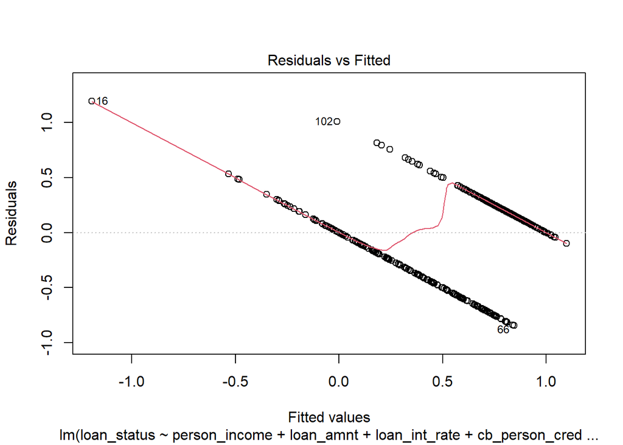

```r
# Plot residuals vs. fitted values
plot(model_fit, which = 1)
```

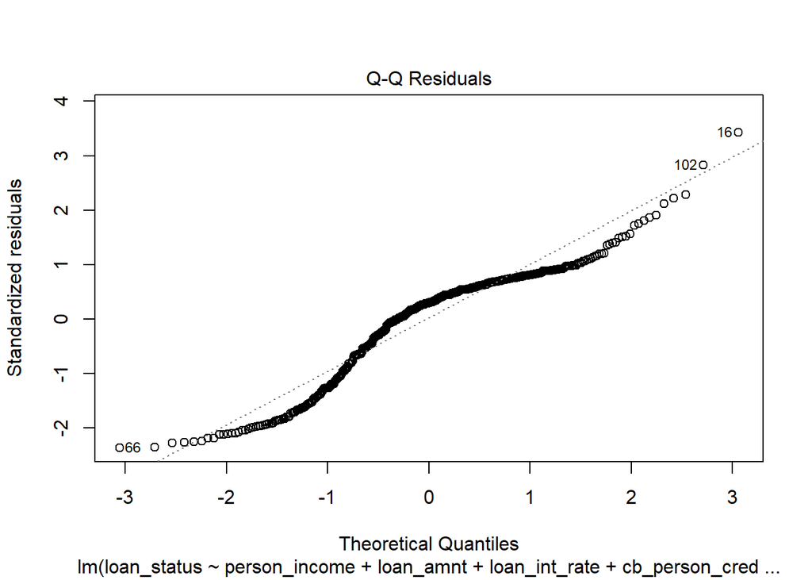

```r
# Plot normal Q-Q plot of residuals
plot(model_fit, which = 2)
```

We see the points are not always normally distributed.

4. Prediction

```r
# Make predictions
predictions <- predict(model_fit, newdata = loan_data)

# Print predictions
print(predictions)
```

```
##            1            2            3            4            5            6
##  1.018628937  0.783323453  0.840552578  0.993432962  0.962746024  0.699348055
##            7            8            9           10           11           12
##  0.837331788  0.762789659  0.757239155  0.843024339  0.716898682  0.757111563
##           13           14           15           16           17           18
##  0.677703058  0.808900645  0.518798660 -1.193412773  0.495939467  0.928167785
##           19           20           21           22           23           24
##  0.783318581  0.782182285  0.291519970  0.712119222  0.975507043  0.653649571
##           25           26           27           28           29           30
##  0.841104343  0.865055633  0.954111319  0.702573603  0.805872657  0.858995214
##           31           32           33           34           35           36
##  0.751046421  0.499639756  0.766019430 -0.289206266 -0.480870441  0.631408961
##           37           38           39           40           41           42
##  1.097769128  0.905611220  0.879571160           NA  1.023665182  0.792954266
##           43           44           45           46           47           48
## -0.488407837 -0.081133446 -0.534004664 -0.217211522 -0.264673942  0.645634948
##           49           50           51           52           53           54
##  0.839728679  0.586048548           NA  0.942275534  0.794606533  0.682772017
##           55           56           57           58           59           60
##  0.442298512 -0.261432622 -0.261170687           NA  0.390672642           NA
##           61           62           63           64           65           66
##  0.344880883 -0.301175850           NA  0.182940874  0.894581814  0.844995597
##           67           68           69           70           71           72
## -0.109238707 -0.062406299 -0.348740548 -0.067753623           NA           NA
##           73           74           75           76           77           78
##  0.830738823  0.739760881  0.604473942  0.703764261  0.650469586  0.806671215
##           79           80           81           82           83           84
##  0.713885624  0.799315152 -0.111980554 -0.248755345  0.664201334  0.558702175
##           85           86           87           88           89           90
##           NA           NA  0.424872035           NA  0.884496119  0.814842141
##           91           92           93           94           95           96
##           NA  0.892283909  0.794387790           NA  0.823742162  0.547016903
##           97           98           99          100          101          102
##  0.803366181  0.778040342 -0.019279063 -0.161992452 -0.029669225 -0.009326877
##          103          104          105          106          107          108
##  0.106219872  0.143302077  0.671010619  0.571733033  0.804865130  0.905604796
##          109          110          111          112          113          114
##           NA  0.775015605  0.732308908 -0.061018516  0.335778567  0.206079688
##          115          116          117          118          119          120
##           NA  0.755068202  0.850521285  0.987518230  0.760762758  0.847082388
```

[output cut: 111 more lines]

```
##  0.496117985  0.769028889  0.580946560  0.879694395  0.454524571  0.453062174
##          457          458          459          460          461          462
##  0.522149467  0.744681705  0.230657852  0.572683915  0.759487140  0.720944889
##          463          464          465          466          467          468
##  0.294157775  0.573995454           NA  0.732706770           NA  0.580149308
##          469          470          471          472          473          474
##  0.803009094  0.867134722  0.593859031  0.741951243           NA  0.904735118
##          475          476          477          478          479          480
##           NA           NA  0.671334045           NA           NA  0.747116356
##          481          482          483          484          485          486
##  0.694253179  0.710173655  0.719569097  0.714843747  0.703527219           NA
##          487          488          489          490          491          492
##  0.744803217  0.730602175  0.815070229  0.752303389  0.941956079  0.802492520
##          493          494          495          496          497          498
##  0.706906300  0.899683749  0.904523898  0.804899892  0.791579965  0.720918709
```

Each predicted weight represents the estimated weight of loan i.e if a person gets it or not, based on its corresponding values of the predictor variables (person_income + loan_amnt + loan_int_rate + cb_person_cred_hist_length + cb_person_default_on_file) as per the fitted regression model.

5. Model Accuracy

```r
# Calculate Mean Squared Error (MSE)
mse <- mean(model_fit$residuals^2)

# Calculate Root Mean Squared Error (RMSE)
rmse <- sqrt(mse)

# Calculate Mean Absolute Error (MAE)
mae <- mean(abs(model_fit$residuals))

# Print the accuracy metrics
cat("Mean Squared Error (MSE):", mse, "\n")
```

```
## Mean Squared Error (MSE): 0.127923
```

```r
cat("Root Mean Squared Error (RMSE):", rmse, "\n")
```

```
## Root Mean Squared Error (RMSE): 0.3576632
```

```r
cat("Mean Absolute Error (MAE):", mae, "\n")
```

```
## Mean Absolute Error (MAE): 0.2890811
```

The MSE is 0.127923, on average, the squared difference between the observed and predicted values.

The RMSE is 0.3576632, suggesting that, on average, the difference between the actual and predicted values.

The MAE is 0.2890811, indicating that, on average, the absolute difference between the actual and predicted values.

Lower values of MSE, RMSE, and MAE indicate better model performance, with smaller differences between actual and predicted values.

```r
#Anova Table
anova(model_fit)
```

```
## Analysis of Variance Table
##
## Response: loan_status
##                             Df Sum Sq Mean Sq  F value    Pr(>F)
## person_income                1 43.701  43.701 337.0247 < 2.2e-16 ***
## loan_amnt                    1  6.111   6.111  47.1296 2.271e-11 ***
## loan_int_rate                1  2.992   2.992  23.0769 2.138e-06 ***
## cb_person_cred_hist_length   1  0.344   0.344   2.6540     0.104
## cb_person_default_on_file    1  0.006   0.006   0.0473     0.828
## Residuals                  440 57.054   0.130
## ---
## Signif. codes:  0 '***' 0.001 '**' 0.01 '*' 0.05 '.' 0.1 ' ' 1
```

```r
vcov(model_fit)
```

```
##                              (Intercept) person_income     loan_amnt
## (Intercept)                 1.023371e-02 -3.818608e-09 -3.252365e-08
## person_income              -3.818608e-09  5.664582e-14 -1.055345e-13
## loan_amnt                  -3.252365e-08 -1.055345e-13  3.472894e-12
## loan_int_rate              -3.965587e-04 -2.490656e-12 -2.014002e-09
## cb_person_cred_hist_length -1.377610e-03 -4.336332e-11  1.734538e-10
## cb_person_default_on_fileY  7.903436e-04  7.170036e-10  1.649109e-10
##                            loan_int_rate cb_person_cred_hist_length
## (Intercept)                -3.965587e-04              -1.377610e-03
## person_income              -2.490656e-12              -4.336332e-11
## loan_amnt                  -2.014002e-09               1.734538e-10
## loan_int_rate               3.658650e-05               3.494271e-06
## cb_person_cred_hist_length  3.494271e-06               4.374008e-04
## cb_person_default_on_fileY -1.231628e-04               5.661757e-05
##                            cb_person_default_on_fileY
## (Intercept)                              7.903436e-04
## person_income                            7.170036e-10
## loan_amnt                                1.649109e-10
## loan_int_rate                           -1.231628e-04
## cb_person_cred_hist_length               5.661757e-05
## cb_person_default_on_fileY               1.998587e-03
```

```r
cov2cor(vcov(model_fit))
```

```
##                            (Intercept) person_income    loan_amnt loan_int_rate
## (Intercept)                  1.0000000  -0.158600542 -0.172519031  -0.648082888
## person_income               -0.1586005   1.000000000 -0.237938576  -0.001730093
## loan_amnt                   -0.1725190  -0.237938576  1.000000000  -0.178670867
## loan_int_rate               -0.6480829  -0.001730093 -0.178670867   1.000000000
## cb_person_cred_hist_length  -0.6511331  -0.008711617  0.004450393   0.027622081
## cb_person_default_on_fileY   0.1747583   0.067386970  0.001979439  -0.455467770
##                            cb_person_cred_hist_length
## (Intercept)                              -0.651133144
## person_income                            -0.008711617
## loan_amnt                                 0.004450393
## loan_int_rate                             0.027622081
## cb_person_cred_hist_length                1.000000000
## cb_person_default_on_fileY                0.060554988
##                            cb_person_default_on_fileY
## (Intercept)                               0.174758324
## person_income                             0.067386970
## loan_amnt                                 0.001979439
## loan_int_rate                            -0.455467770
## cb_person_cred_hist_length                0.060554988
## cb_person_default_on_fileY                1.000000000
```

```r
temp <- influence.measures(model_fit)
temp
```

```
## Influence measures of
##   lm(formula = loan_status ~ person_income + loan_amnt + loan_int_rate +      cb_person_cred_hist_length + cb_person_default_on_file, data = loan_data) :
##
##        dfb.1_  dfb.prs_  dfb.ln_m  dfb.ln__ dfb.cb____ dfb.c____Y    dffit
## 1    1.19e-03  0.002220 -4.01e-03 -1.50e-04  -3.53e-04  -3.37e-03 -0.00658
## 2   -1.82e-01  0.090599  1.73e-01 -1.63e-02   1.37e-01   6.37e-02 -0.28646
## 3    9.60e-03 -0.020966 -2.66e-02  1.51e-02  -1.18e-03  -1.71e-02  0.04668
## 4    2.57e-05 -0.000849  1.43e-03  8.25e-04  -1.10e-03  -1.06e-03  0.00241
## 5   -4.32e-03 -0.004830  8.71e-03 -2.63e-03   6.76e-03   8.54e-03  0.01520
## 6    1.06e-01 -0.036005 -4.94e-02 -5.21e-02  -5.40e-02   1.68e-03  0.11784
## 7   -3.22e-03 -0.017596  3.83e-02 -4.93e-04  -1.17e-03  -1.44e-02  0.04697
## 8   -2.06e-02 -0.025250  5.87e-02 -1.43e-02   3.67e-02  -1.20e-02  0.07913
## 9    4.70e-02 -0.023368  6.41e-02 -4.24e-02  -4.27e-02  -5.42e-03  0.09153
## 10   2.01e-03 -0.018548 -3.78e-02  3.05e-02  -8.27e-04  -2.33e-02  0.05779
## 11  -1.86e-02 -0.026951  7.11e-02 -2.70e-02   4.35e-02  -9.59e-03  0.09584
```

[output cut: 882 more lines]

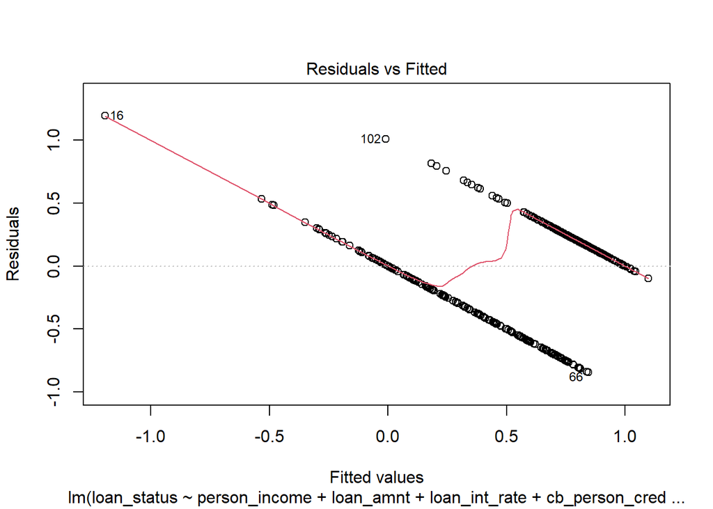

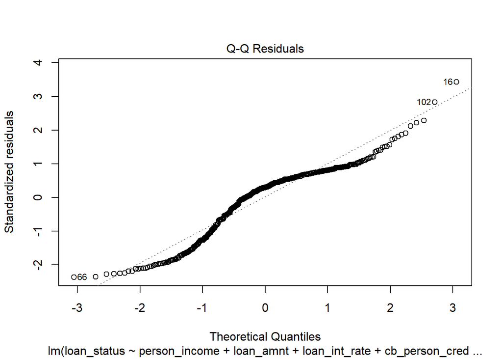

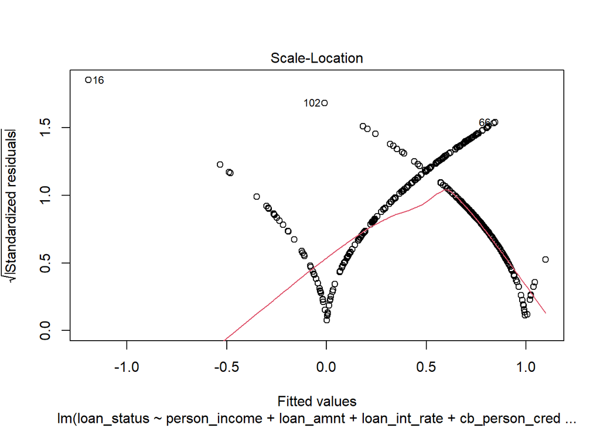

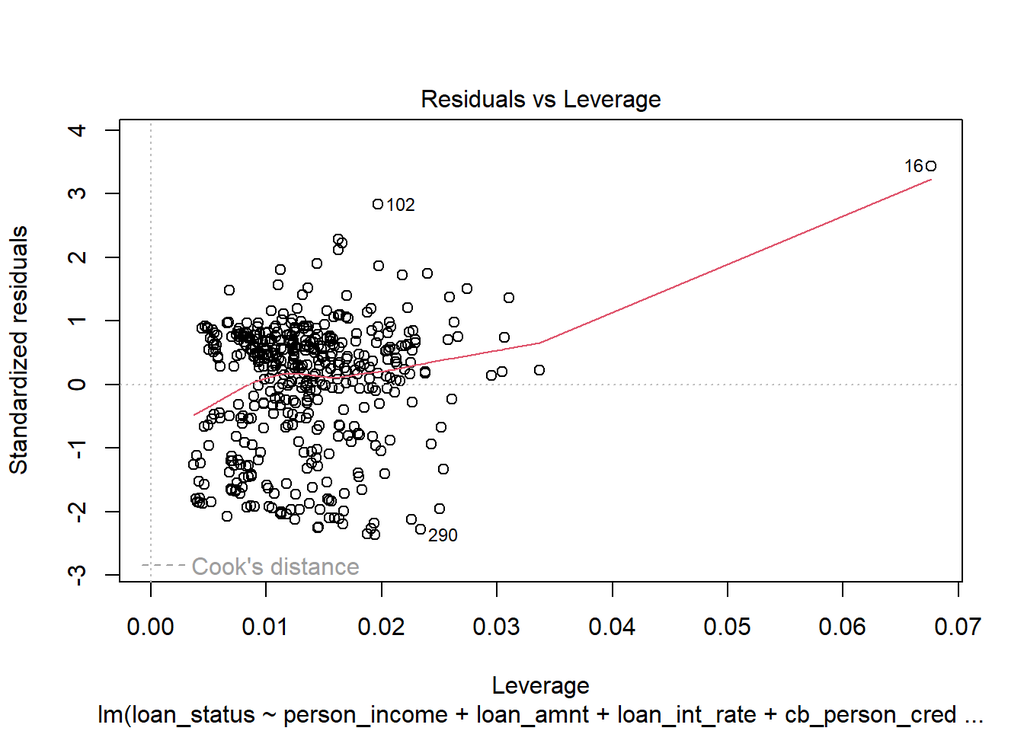

```r
plot(model_fit)
```

```r
anova_result <- anova(model_fit)
print(anova_result)
```

```
## Analysis of Variance Table
##
## Response: loan_status
##                             Df Sum Sq Mean Sq  F value    Pr(>F)
## person_income                1 43.701  43.701 337.0247 < 2.2e-16 ***
## loan_amnt                    1  6.111   6.111  47.1296 2.271e-11 ***
## loan_int_rate                1  2.992   2.992  23.0769 2.138e-06 ***
## cb_person_cred_hist_length   1  0.344   0.344   2.6540     0.104
## cb_person_default_on_file    1  0.006   0.006   0.0473     0.828
## Residuals                  440 57.054   0.130
## ---
## Signif. codes:  0 '***' 0.001 '**' 0.01 '*' 0.05 '.' 0.1 ' ' 1
```